# 统计计算 Homework-10 报告

林子开 21307110161

2023年12月

# Exercise 9.6

```r
set.seed(2023)

# use the random walk Metropolis sampler with a uniform proposal chain
# theta should be within [0,1]
w <- 0.25  # width of the uniform support set
m <- 5000  # length of the chain
burn <- 1000  # burn-in time
x <- numeric(m)  # the chain

# the following function prob computes the target density
# (without the constant)

prob <- function(theta,animals){
  # computes (without the constant) the target density
  if (theta<0 || theta>1)
    return(0)
  ratio <- (1/2 + theta/4)^animals[1] * ((1-theta)/4)^animals[2] *
            ((1-theta)/4)^animals[3] * (theta/4)^animals[4]
}

# generate the random walk Metropolis chain
animals <- c(125, 18, 20, 34)
u <- runif(m) # for accept/reject step
v <- runif(m,-w,w)  # proposal distribution
x[1] <- 0.5
for (i in 2:m){
  y <- x[i-1] + v[i]
  if (u[i]<= prob(y,animals)/prob(x[i-1],animals))
    x[i] <- y # accept
  else
    x[i] <- x[i-1] # reject
}
```

The posterior mean of $\theta$ with the burn-in stage discarded is:

```r
xb <- x[(burn+1):m]
print(mean(xb))
```

```
## [1] 0.6232126
```

The following is the posterior distributionof $\theta$ given the observed sample:

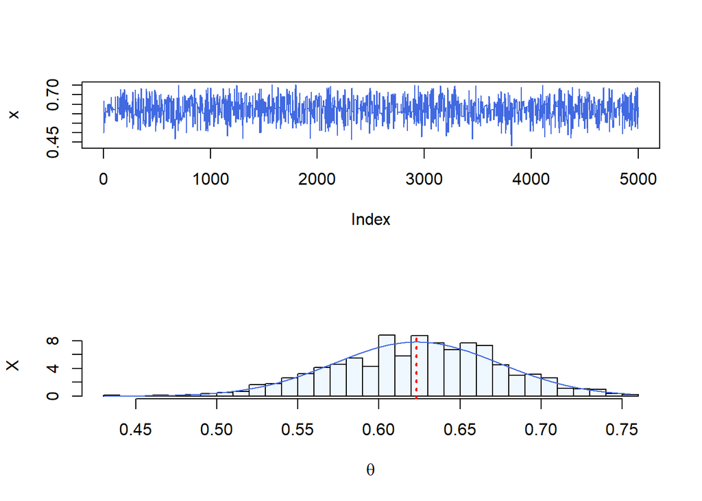

```r
par(mfrow=c(2,1))
plot(x,type='l',col='royalblue')
hist(xb,prob=T,breaks = 'scott',xlab=bquote(theta),ylab='X',main='',col='aliceblue')
z <- seq(min(xb),max(xb),length=1000)
lines(z,dnorm(z,mean(xb),sd(xb)),col='royalblue')
abline(v=mean(xb),col='red',lwd=2,lty=3)
```

# Exercise 9.7

```r
set.seed(2023)

# initialize constants and parameters
N <- 5000
burn <- 1000
X <- matrix(0,N,2)

rho <- .9
mu2 <- mu1 <- 0
sigma2 <- sigma1 <- 1
s2 <- s1 <- sqrt(1-rho^2)*sigma1

# generate the chain
X[1,] <- c(mu1,mu2) # initialize
for ( i in 2:N){
  x2 <- X[i-1,2]
  m1 <- mu1 + rho*(x2 - mu2)*sigma1/sigma2
  X[i,1] <- rnorm(1,m1,s1)
  x1 <- X[i,1]
  m2 <- mu2 + rho*(x1 - mu1) * sigma2/sigma1
  X[i,2] <- rnorm(1,m2,s2)
}
```

Plot the generated sample after discardinga suitable burn-in sample:

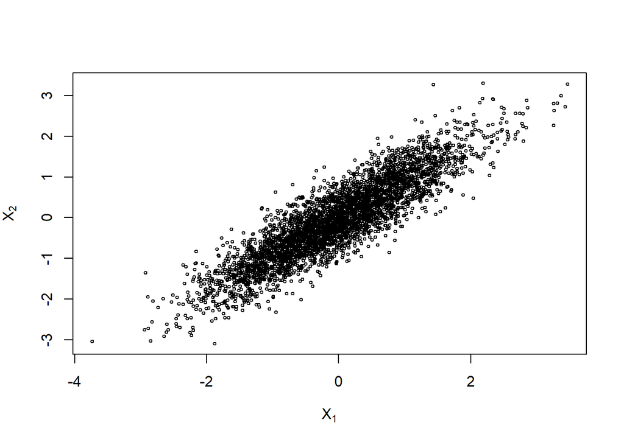

```r
b <- burn + 1
x <- X[b:N,]
plot(x,main='',cex=.5, xlab=bquote(X[1]),ylab=bquote(X[2]),xlim=range(x[,1]),ylim=range(x[,2]))
```

Fit a simple linear regression model $Y=\beta_0+\beta_1X$:

```r
x.dataframe <- as.data.frame(x)
colnames(x.dataframe) <- c('Y','X')
model <- lm(Y~.,x.dataframe)
summary(model)
```

```
##
## Call:
## lm(formula = Y ~ ., data = x.dataframe)
##
## Residuals:
##      Min       1Q   Median       3Q      Max
## -1.72731 -0.28841 -0.00076  0.28785  1.61155
##
## Coefficients:
##             Estimate Std. Error t value Pr(>|t|)
## (Intercept) 0.003979   0.006883   0.578    0.563
## X           0.889988   0.007031 126.572   <2e-16 ***
## ---
## Signif. codes:  0 '***' 0.001 '**' 0.01 '*' 0.05 '.' 0.1 ' ' 1
##
## Residual standard error: 0.4349 on 3998 degrees of freedom
## Multiple R-squared:  0.8003, Adjusted R-squared:  0.8002
## F-statistic: 1.602e+04 on 1 and 3998 DF,  p-value: < 2.2e-16
```

Finally, check the residuals of the model for normality and constant variance.

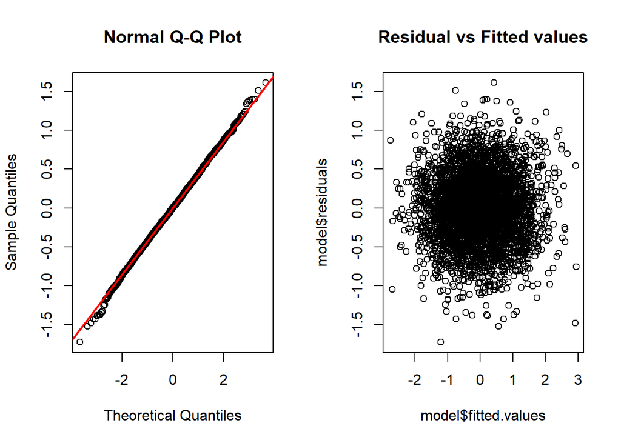

```r
par(mfrow=c(1,2))
qqnorm(model$residuals)
qqline(model$residuals,col='red',lwd=2)
plot(model$fitted.values,model$residuals,main='Residual vs Fitted values')
```

# Exercise 9.8

```r
set.seed(2023)

chain <- function(n,a,b,x,y,N){

  X <- matrix(0,N,2) # to store the chain

  # generate the chain
  X[1,] <- c(1,0.5) # initialize the chain
  for (i in 2:N){
    x2 <- X[i-1,2]
    X[i,1] <- rbinom(1,n,y)
    # print(y)
    x1 <- X[i,1]
    X[i,2] <- rbeta(1,shape1=x+a, shape2=n-x+b)
  }

  return(X)
}

burn <- 1000
N <- 5000 # length of the chain
n <- 20
a <- 10
b <- 10

X <- chain(n,a,b,x=10,y=0.5,N)
```

Plot the samples generated from the target joint density $f(x,y)$, with burn-in time samples discarded

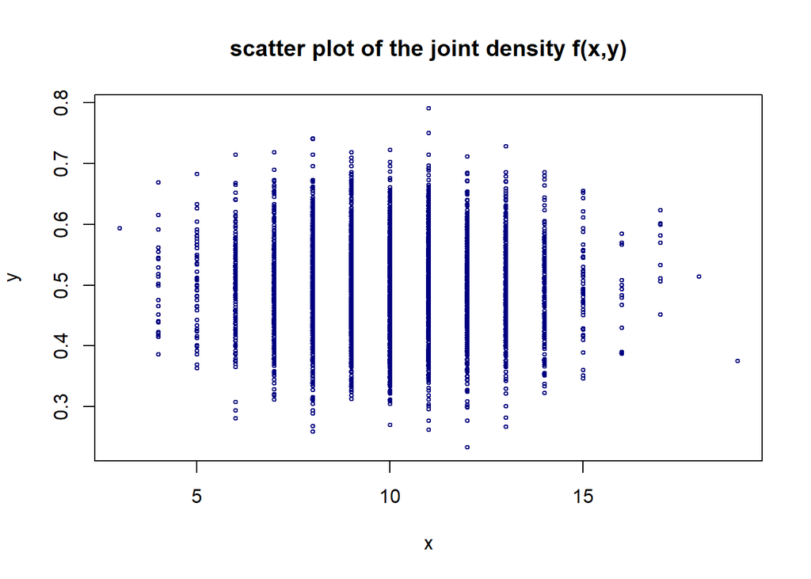

```r
Xb <- X[(burn + 1):N,] # drop the burn-in time samples

x <- Xb[,1]
y <- Xb[,2]
par(mfrow=c(1,1))
plot(Xb,cex=.5,type = 'p',xlab=bquote(x),ylab=bquote(y),
     col='navyblue',main='scatter plot of the joint density f(x,y)')
```

Plot the chain and histogram of x

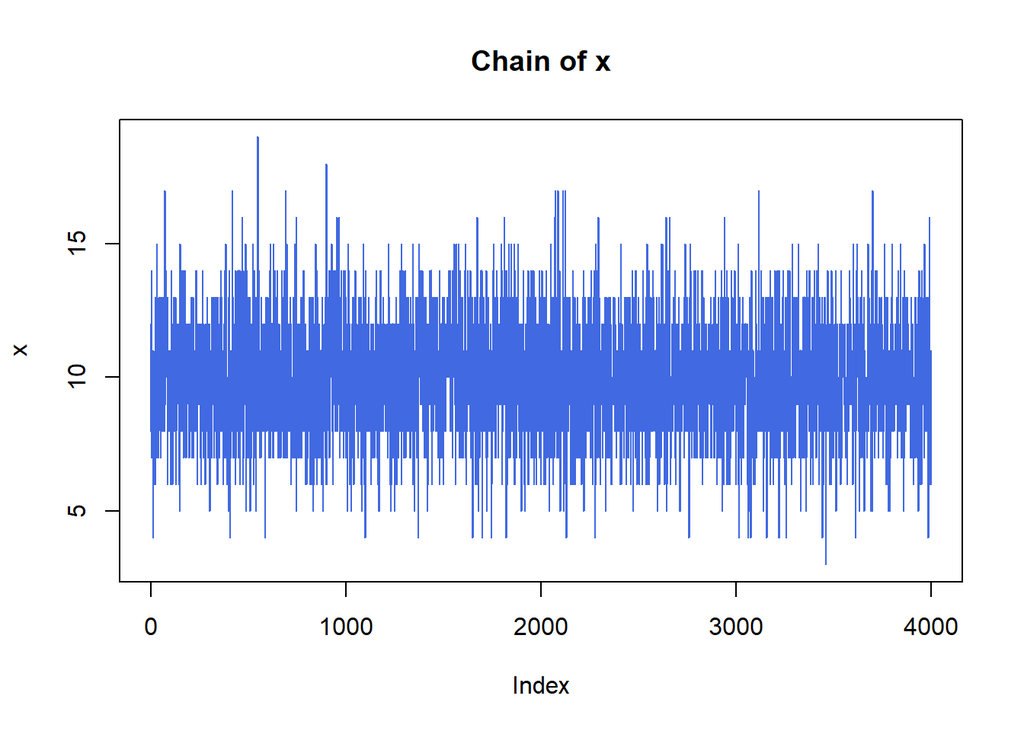

```r
plot(x,type='l',col='royalblue',main='Chain of x')
```

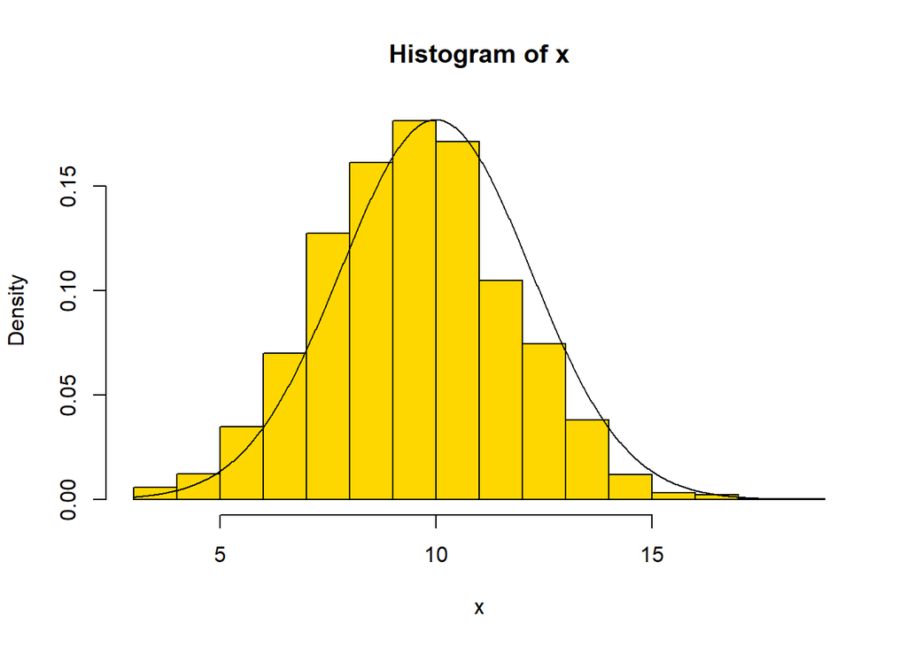

```r
hist(x,probability = T,col='gold')
z <- seq(min(x),max(x),length=1000)
lines(z,dnorm(z,mean=mean(x),sd=sd(x)))
```

Plot the chain and histogram of y

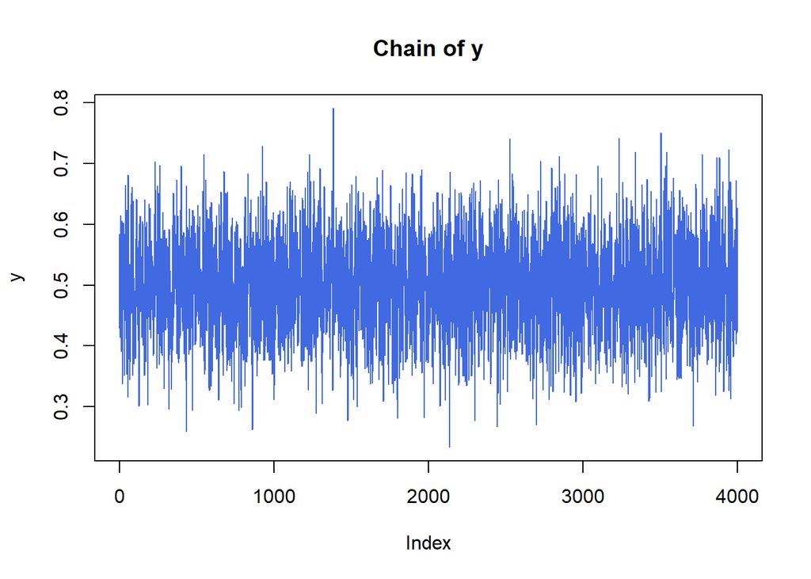

```r
plot(y,type='l',col='royalblue',main='Chain of y')
```

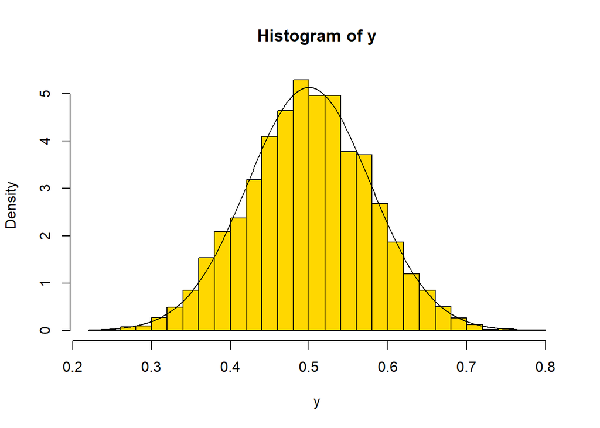

```r
hist(y,probability = T,breaks='scott',col='gold')
z <- seq(min(y),max(y),length=1000)
lines(z,dnorm(z,mean=mean(y),sd=sd(y)))
```

```r
par(mfrow=c(1,1))
```

# Exercise 9.10

```r
set.seed(233333)

Gelman.Rubin <- function(psi){
  # psi[i,j] is the statistic psi(X[i,1:j])
  # for chain in i-th row of X
  psi <- as.matrix(psi)
  n <- ncol(psi)
  k <- nrow(psi)

  psi.means <- rowMeans(psi) # row means
  B <- n * var(psi.means)  # between variance est.
  psi.w <- apply(psi,1,'var') # within est.
  W <- mean(psi.w) # within est.
  v.hat <- W*(n-1)/n + (B/n) # upper variance est.
  r.hat <- v.hat/W # G-R statistic
  return(r.hat)
}



Rayleigh.chain <- function(sigma=4,N=10000,X1=1){
  # generates a Metropolis chain for Rayleigh distribution

  f<-function(x,sigma){
    # calculate the density of Rayleigh distribution
    if (any(x<0)) return(0)
    stopifnot(sigma>0)
    return( (x/sigma^2) * exp(-x^2/(2*sigma^2)) )
  }

  x <- numeric(N)
  x[1] <- X1
  u <- runif(N)

  for(i in 2:N){
    xt <- x[i-1]
    y <- rchisq(1, df=xt)
    num <- f(y,sigma) * dchisq(xt, df=y)
    den <- f(xt,sigma) * dchisq(y, df=xt)
    if (u[i] <= num/den)
      x[i] <- y
    else
      x[i] <- xt # y is rejected
  }
  return(x)
}

sigma <- 4 # parameter of Rayleigh distribution
k <- 4 # number of chains to generate
n <- 4000 # length of chains
b <- 1000 # burn-in length

# choose overdispersed initial values
x0 <- c(5,10,15,20)

# generate the chain
X <- matrix(0,nrow=k,ncol=n)
for(i in 1:k)
  X[i,] <- Rayleigh.chain(sigma,n,x0[i]) # each row is a chain

# compute the diagnostic statistics
psi <- t(apply(X,1,cumsum))
for(i in 1:nrow(psi))
  psi[i,] <- psi[i,] / (1:ncol(psi)) # cummulated mean
print(Gelman.Rubin(psi))
```

```
## [1] 1.175621
```

Plot the sequence of $\hat{R}$ with the burn-in time discarded:

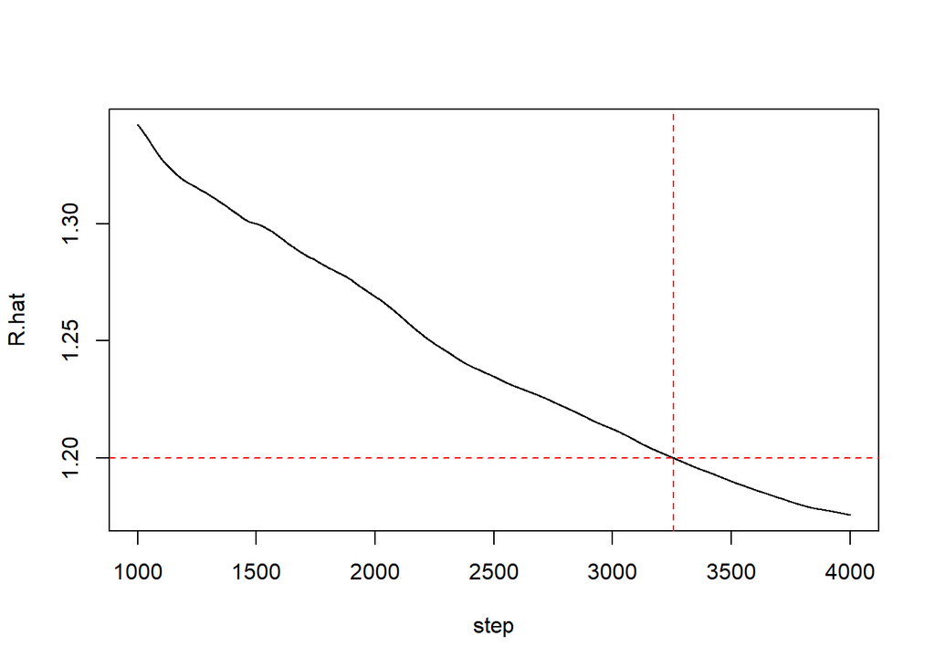

```r
rhat <- rep(0,n)
find.flag = FALSE
for(j in (b+1):n){
  rhat[j] <- Gelman.Rubin(psi[,1:j])
  if (rhat[j] < 1.2 && !find.flag){
    k = j # find the index of step where R is less than 1.2 for the first time
    find.flag = TRUE
  }
}
plot((b+1):n,rhat[(b+1):n],type='l',xlab='step',ylab='R.hat')
abline(h=1.2,v=k,lty=2,col='red')
```

And the step of the chain when $\hat{R}<1.2$ for the first time is:

```r
print(k)
```

```
## [1] 3256
```

Use the coda $\texttt{coda}$ package to check for convergence

```r
# use the coda package to check for the convergence of the chain
library(coda)
X.chain.1 <- as.mcmc(X[1,])
X.chain.2 <- as.mcmc(X[2,])
X.chain.3 <- as.mcmc(X[3,])
X.chain.4 <- as.mcmc(X[4,])
X.chain <- mcmc.list(X.chain.1,X.chain.2,X.chain.3,X.chain.4)

gelman.diag(X.chain)
```

```
## Potential scale reduction factors:
##
##      Point est. Upper C.I.
## [1,]          1       1.01
```

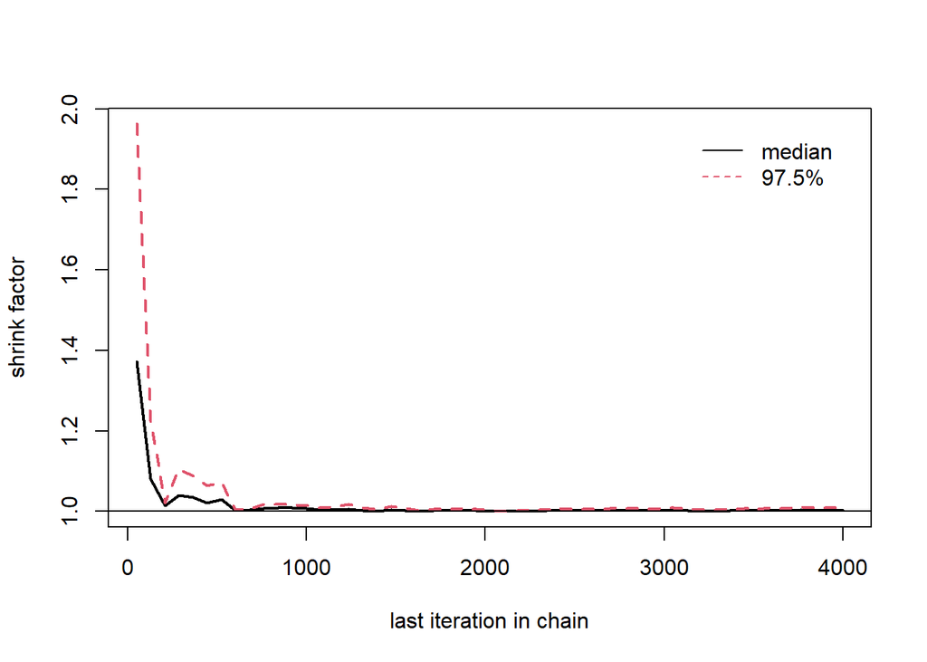

```r
gelman.plot(X.chain,lwd=2)
```

# Explain why Gibbs sampler is a special case of Metropolis-Hastings algorithm

Consider the following transition:
$$(x_1^{(t)},\cdots,x_{k-1}^{(t)},x_k^{(t-1)},x_{k+1}^{(t-1)},\cdots,
x_d^{(t-1)}) \longrightarrow
(x_1^{(t)},\cdots,x_{k-1}^{(t)},x_k^{(t)},x_{k+1}^{(t-1)},\cdots,
x_d^{(t-1)})$$
We denote the above transition as
$$X\longrightarrow X^*$$
Furthermore, we define the $(d-1)$ dimensional random vectors:
$$X_{(-k)} = X^*_{(-k)} =
(x_1^{(t)},\cdots,x_{k-1}^{(t)},x_{k+1}^{(t-1)},\cdots, x_d^{(t-1)})$$

In Gibbs sampler, the **proposal** is
$$g(X^*|X) = f(x_k|X_{(-k)})$$

And the **accepted probability** is
$$\begin{align*}
\alpha(X,X^*) &= \min \left\{ 1, \frac{f(X^*)g(X|X^*)}
{f(X)g(X^*|X)} \right\} \\
&= \min \left\{ 1,
\frac{f(X^*_{(-k)})f(x_{k}^{(t)}|X_{(-k)}^*) f(x_{k}^{(t-1)}|X_{(-k)}^*)
}
{f(X_{(-k)})f(x_{k}^{(t-1)}|X_{(-k)}) f(x_{k}^{(t)}|X_{(-k)}) }\right\}
\\
& = 1
\end{align*}$$
The second equation holds because
$$f(X^*) = f(X^*_{(-k)})f(x_{k}^{(t)}|X_{(-k)}^*), \;
f(X) =f(X_{(-k)}) f(x_{k}^{(t-1)}|X_{(-k)})$$
And the last equation holds because $X_{(-k)} = X^*_{(-k)}$.

Therefore, every candidate is accepted in Gibbs sampler, and Gibbs sampler is a special case of the Metropolis-Hastings sampler.